# Activity quality recognition

Arjuna Rao C

September 26, 2015

## Executive Summary

Weight Lifting Exercises Dataset is used for assessing the performance of various machine learning algorithms. In our study random forest algorithm provided better performance than linear discriminant analysis algorithm. The report highlights the various steps for applying machine learning algorithms

## Data Set

Velloso E et.al [1] explored the use of human activity data for identifying the proper way of doing activity. They considered a simple weight lifting activity with one correct way and four incorrect ways. Participants were instrumented with 9 DOF sensors on belt, forearm, arm. The dumb bell was also instrumented with 9 DOF sensor. Raw Data from these sensors was captured. various statistical features such as mean, standard deviation, kutosis were computed for small windows of activity duration with 0.5 second overlap. Physical features representing the physical motion were also computed.

```r
library(caret)
library(doMC)
registerDoMC(cores=2)
training<-read.csv("pml-training.csv",header=TRUE,na.strings=c("NA",""))
testing<-read.csv("pml-testing.csv",header=TRUE,na.strings=c("NA",""))
training<-training[,8:160]
testing <-testing [,8:160]
#remove mostly NA columns
NAcolindex<-apply(!is.na(training),2,sum) >19621
training1<-training[,NAcolindex]
testing1<-testing[,NAcolindex]
#remove DIVBY0 rows
training1<-training1[apply(training1, 1, function(x) !any(x == '#DIV/0!')), ]
dim(training1)
```

```
## [1] 19622    53
```

## Pre Processing

```r
#check near zero variance predictors
nzvtr1<-nzv(training1,saveMetrics = TRUE)
summary(nzvtr1)
```

```
##    freqRatio      percentUnique       zeroVar           nzv
##  Min.   : 1.000   Min.   : 0.02548   Mode :logical   Mode :logical
##  1st Qu.: 1.036   1st Qu.: 1.41678   FALSE:53        FALSE:53
##  Median : 1.079   Median : 3.27693   NA's :0         NA's :0
##  Mean   : 6.002   Mean   : 8.88241
##  3rd Qu.: 1.140   3rd Qu.: 7.76679
##  Max.   :87.256   Max.   :84.20650
```

```r
#None of the variables have near zero variance
```

We tried to find predictors with near zero variance, so that they can be left out from the model. We found none that could be dropped.

## Create training, test datasets

```r
##Create training and test sets from the initial training dataset
set.seed(1234)
inTrain<-createDataPartition(training1$classe,p=0.75,list=FALSE)
trnset<-training1[inTrain,]
tstset<-training1[-inTrain,]
```

Training and Testing datasets were created with 75:25 proportion resulting in 14718 samples for training and 4904 samples for testing(hold out data).

## Check correlation between columns

```r
dim(trnset)
```

```
## [1] 14718    53
```

```r
cormat<-cor(trnset[,-53])
#identify predictors which are correlated by more than 0.9
highCorrDescr <- findCorrelation(cormat,cutoff=0.9)
trnset<-trnset[,-highCorrDescr]
#dimenstions after removing the highly correlated descriptors
dim(trnset)
```

```
## [1] 14718    46
```

```r
tstset<-tstset[,-highCorrDescr]
```

Highly correlated variates were identified and they were dropped from the dataset.The variates have been reduced to 46.

## Linear Discriminant Analysis Model

```r
ldaFit<-train(classe~.,data=trnset,method="lda")
print(ldaFit)
```

```
## Linear Discriminant Analysis
##
## 14718 samples
##    45 predictors
##     5 classes: 'A', 'B', 'C', 'D', 'E'
##
## No pre-processing
## Resampling: Bootstrapped (25 reps)
## Summary of sample sizes: 14718, 14718, 14718, 14718, 14718, 14718, ...
## Resampling results
##
##   Accuracy   Kappa      Accuracy SD  Kappa SD
##   0.6759421  0.5894919  0.005873841  0.007461685
##
##
```

```r
confusionMatrix(predict(ldaFit,newdata=tstset),tstset$classe)
```

```
## Confusion Matrix and Statistics
##
##           Reference
## Prediction    A    B    C    D    E
##          A 1143  168   97   48   52
##          B   37  585   76   55  147
##          C  108   96  536   90   93
##          D  102   36  120  565  111
##          E    5   64   26   46  498
##
## Overall Statistics
##
##                Accuracy : 0.6784
##                  95% CI : (0.6651, 0.6915)
##     No Information Rate : 0.2845
##     P-Value [Acc > NIR] : < 2.2e-16
##
##                   Kappa : 0.5924
##  Mcnemar's Test P-Value : < 2.2e-16
##
## Statistics by Class:
##
##                      Class: A Class: B Class: C Class: D Class: E
## Sensitivity            0.8194   0.6164   0.6269   0.7027   0.5527
## Specificity            0.8960   0.9204   0.9044   0.9100   0.9648
## Pos Pred Value         0.7580   0.6500   0.5807   0.6049   0.7793
## Neg Pred Value         0.9258   0.9091   0.9199   0.9398   0.9055
## Prevalence             0.2845   0.1935   0.1743   0.1639   0.1837
## Detection Rate         0.2331   0.1193   0.1093   0.1152   0.1015
## Detection Prevalence   0.3075   0.1835   0.1882   0.1905   0.1303
## Balanced Accuracy      0.8577   0.7684   0.7657   0.8064   0.7587
```

LDA is an example of model based prediction. It assumes that variates are gaussian distributed and their covariance is same for each class. This method provided in sample accuracy of 67.5%, with 3 sigma bounds as 0.658 and 0.695. As all the predictors may not meet the assumptions, we can expect lesser accuracy on out of sample data. The out of sample accuracy was found to be slightly higher at 67.8%. So we will consider random Forest model for better accuracy.

## Random Forest model fit

```r
#Sys.time()
#read from precomputed file,
#it took 8:50 hours on
#Intel® Core™2 Duo CPU E7200 @ 2.53GHz × 2 -32 bit ubuntu system with 2 GB memory, with
#parallel processing enabled for 14K rows and 48 predictors
#with 25 bootstrap samples and mtry 3
#with 10 bootstrap samples it took only 36 minutes
#set.seed(1234)
#rfFit<-train(classe~.,data=trnset,method="rf",trControl=trainControl(method="boot",number=10))
#save(rfFit,file="rfFit.precomputed")
#Sys.time()
load("rfFit.precomputed")
print(rfFit)
```

```
## Random Forest
##
## 14718 samples
##    45 predictors
##     5 classes: 'A', 'B', 'C', 'D', 'E'
##
## No pre-processing
## Resampling: Bootstrapped (10 reps)
## Summary of sample sizes: 14718, 14718, 14718, 14718, 14718, 14718, ...
## Resampling results across tuning parameters:
##
##   mtry  Accuracy   Kappa      Accuracy SD  Kappa SD
##    2    0.9888423  0.9858865  0.001960657  0.002481377
##   23    0.9893271  0.9865007  0.001153161  0.001458129
##   45    0.9774172  0.9714340  0.005374998  0.006803121
##
## Accuracy was used to select the optimal model using  the largest value.
## The final value used for the model was mtry = 23.
```

```r
confusionMatrix(predict(rfFit,newdata=tstset),tstset$classe)
```

```
## Confusion Matrix and Statistics
##
##           Reference
## Prediction    A    B    C    D    E
##          A 1395    1    0    0    0
##          B    0  948    1    0    0
##          C    0    0  853    0    0
##          D    0    0    1  804    1
##          E    0    0    0    0  900
##
## Overall Statistics
##
##                Accuracy : 0.9992
##                  95% CI : (0.9979, 0.9998)
##     No Information Rate : 0.2845
##     P-Value [Acc > NIR] : < 2.2e-16
##
##                   Kappa : 0.999
##  Mcnemar's Test P-Value : NA
##
## Statistics by Class:
##
##                      Class: A Class: B Class: C Class: D Class: E
## Sensitivity            1.0000   0.9989   0.9977   1.0000   0.9989
## Specificity            0.9997   0.9997   1.0000   0.9995   1.0000
## Pos Pred Value         0.9993   0.9989   1.0000   0.9975   1.0000
## Neg Pred Value         1.0000   0.9997   0.9995   1.0000   0.9998
## Prevalence             0.2845   0.1935   0.1743   0.1639   0.1837
## Detection Rate         0.2845   0.1933   0.1739   0.1639   0.1835
## Detection Prevalence   0.2847   0.1935   0.1739   0.1644   0.1835
## Balanced Accuracy      0.9999   0.9993   0.9988   0.9998   0.9994
```

With random forest algorithm, there is danger of overfitting. In sample accuracy was found to be 98.9% with 3 sigma bounds as 0.985 and 0.992. As we used 10 resamples instead of the usual 25 resamples to reduce the computation time, the overfitting effect may not be very significant and expect accuracy similar to in sample accuracy. We found the out of sample accuracy as 0.999. More details on the important variables and plots are given below.

## Variable importance and plots

```r
head(varImp(rfFit$finalModel))
```

```
##                     Overall
## pitch_belt        816.66926
## yaw_belt         1193.90466
## total_accel_belt  227.03469
## gyros_belt_x       66.18526
## gyros_belt_y       80.90144
## gyros_belt_z      346.16497
```

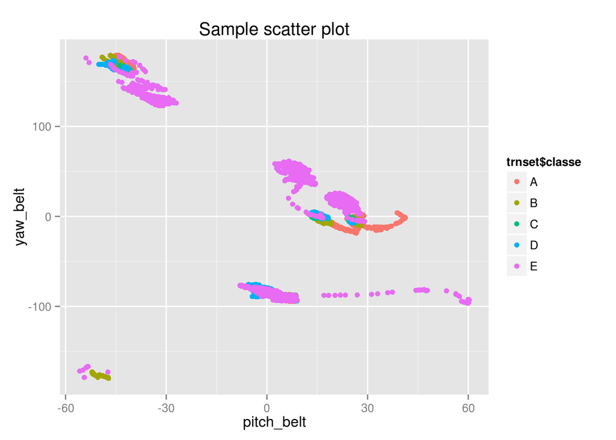

```r
qplot(pitch_belt,yaw_belt,data=trnset,col=trnset$classe,main="Sample scatter plot")
```

Important variables are pitch_belt, yaw_belt. A sample scatter plot of these variables is shown, which indicates the clusters of the classes.

## Prediction on the validation set

```r
predict(rfFit,newdata=testing1)
```

```
##  [1] B A B A A E D B A A B C B A E E A B B B
## Levels: A B C D E
```

The prediction had 100% accuracy when these were submitted as part of programming assignment.

## References

[1] Velloso, E.; Bulling, A.; Gellersen, H.; Ugulino, W.; Fuks, H. Qualitative Activity Recognition of Weight Lifting Exercises. Proceedings of 4th International Conference in Cooperation with SIGCHI (Augmented Human ’13) . Stuttgart, Germany: ACM SIGCHI, 2013.

Read more: http://groupware.les.inf.puc-rio.br/har#sbia_paper_section#ixzz3mkBE0rGJ